# Universidad Nacional de Colombia - Especialización en Analítica

Materia:Decisiones Bajo Incertidumbre en las Organizaciones

Profesor:Daniel Henao - Alumno:Mauricio Correa Arango

20 de mayo de 2019

## Simulación Montecarlo en R

### Objetivo:¿Cuantos sartenes especiales comprar?

### 1. Enunciado resumido del ejercicio

María es Directora de Compras de artículos del hogar en un gran almacén ‘El Roble’. El problema de María es que debe decidir cuántos sartenes especiales debe pedir, sin saber por adelantado cuál será la demanda correspondiente. María está interesada en determinar de qué manera el número de sartenes que ordenará afectará la utilidad esperada de la promoción y la posibilidad de que la promoción gane dinero.

Por lo anterior se realizará una simulación montecarlo en la que representaran 1000 opciones de compra para cada una de las siguientes cantidades de sartenes 95,110,115 respectivamente.

### 2. Histogramas por cada opción de compra

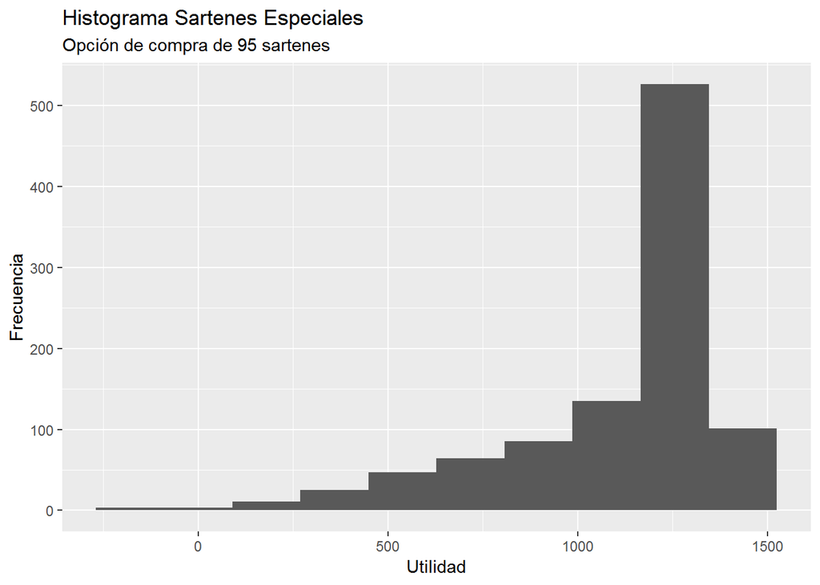

Datos de distrubución compra 95 sartenes especiales

| curtosis | asimitria |
| --- | --- |
| 5.261358 | -1.620879 |

```
## [1] "La simulación para la compra de 95 sartenes posee una asimetría negativa de  -1.620879 , indicando que la cola de la distribución apunta hacia la izquierda."
```

```
## [1] "La simulación para la compra de 95 sartenes posee una curtosis positiva de  5.261358 , indicando que tiene una distribución leptocúrtica."
```

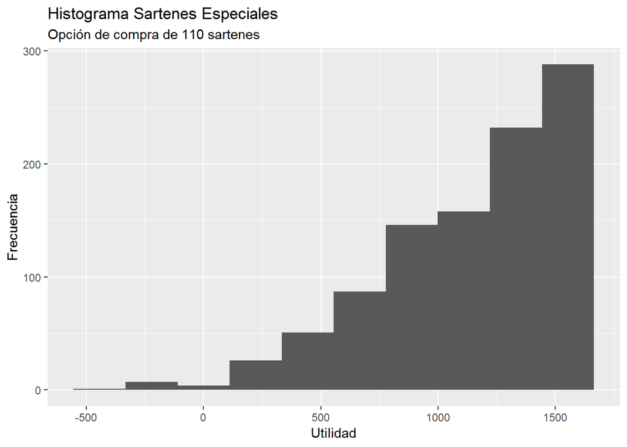

Datos de distrubución compra 110 sartenes especiales

|  | curtosis | asimitria |
| --- | --- | --- |
| 2 | 3.662817 | -1.049722 |

```
## [1] "La simulación para la compra de 110 sartenes posee una asimetría negativa de  -1.049722 , indicando que la cola de la distribución apunta hacia la izquierda."
```

```
## [1] "La simulación para la compra de 110 sartenes posee una curtosis positiva de  3.662817 , indicando que tiene una distribución leptocúrtica."
```

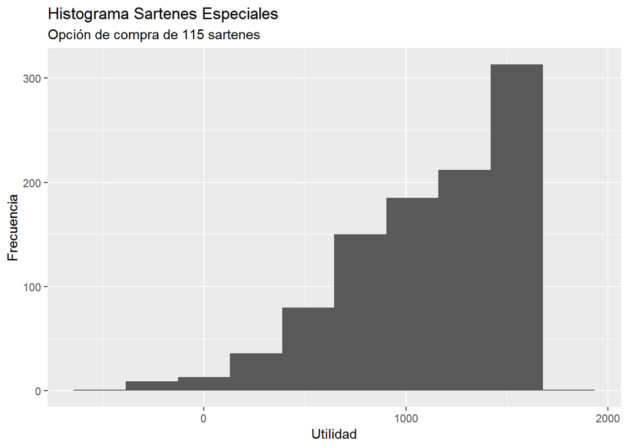

Datos de distrubución compra 115 sartenes especiales

|  | curtosis | asimitria |
| --- | --- | --- |
| 3 | 3.341292 | -0.8816883 |

```
## [1] "La simulación para la compra de 115 sartenes posee una asimetría negativa de  -0.881688 , indicando que la cola de la distribución apunta hacia la izquierda."
```

```
## [1] "La simulación para la compra de 115 sartenes posee una curtosis positiva de  3.341292 , indicando que tiene una distribución leptocúrtica."
```

### 3. Datos estadísticos consolidados de la simulación

| Opcion | Valor_Esperado | Desviacion_Estandar | Minimo | Maximo | Probalidad.Mayor.a.0 | Percentil_05 | Percentil_95 |
| --- | --- | --- | --- | --- | --- | --- | --- |
| Comprar 95 | 1114.448 | 286.1657 | -153.8446 | 1460 | 0.996 | 490.1205 | 1367 |
| Comprar 110 | 1136.400 | 376.6540 | -375.6140 | 1622 | 0.990 | 393.4910 | 1523 |
| Comprar 115 | 1113.063 | 410.9814 | -638.2901 | 1684 | 0.987 | 363.4066 | 1573 |

### 4. ¿Cual decisión es la ganadora según cada criterio de incertidumbre?

Los datos arrojados por dicha simulación se visualizan en la tabla anterior. Esta tabla tiene el campo ‘probalidad > 0’, la información de esta columna hace referencia a la robustez, que nos indica de las 1000 iteraciones en que porcentaje de probabilidad se va obtener utilidad. Analizando los demás datos estadisticos se visualiza que para la compra de 95 sartenes el cual presenta la mayor robustez, el 95% de los datos esta por debajo de 1367 de utilidad. Es decir que solo se tiene una probailidad del 5% de obtener utilidades por encima de este valor. Interpretando las dos otras dos propuestas de compra (110 y 115) se evidencia que si bien presentan menor robustez que la compra de 95 sartenes, pueden proporcionar una mayor utilidad, para estos dos pedidos la utilidad máxima es superior a 1620. Finalmente si se compara el pedido de 110 vs 115 este primero presenta un valor esperado más alto (1136.40 vs 1113.06) y una desviación estandar más baja, lo que quiere decir que la dispersión de las utilidades respecto a la media es menor para el pedio de 110. Por lo anterior se le recomienda a Maria comprar una cantidad de 110 Sartenes.